# Tidy Text Notebook

# Wordclouds

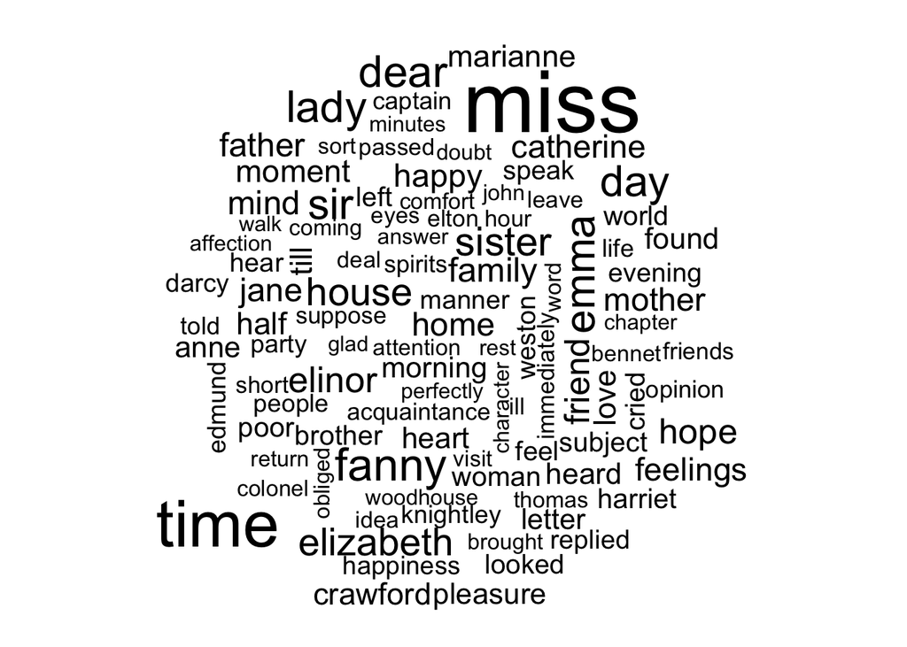

```r
library(wordcloud)
tidy_books %>%
  anti_join(stop_words) %>%
  count(word) %>%
  with(wordcloud(word, n, max.words = 100))
```

```r
library(reshape2)
```

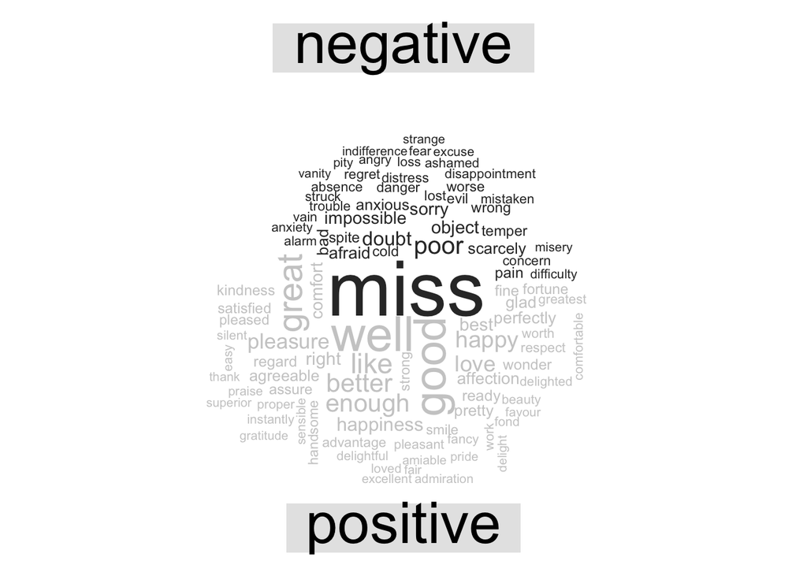

```r
tidy_books %>%
  inner_join(get_sentiments("bing")) %>%
  count(word, sentiment, sort = TRUE) %>%
  acast(word~sentiment, value.car = "n", fill = 0) %>%
  comparison.cloud(colors = c("gray20", "gray80"),
                   max.words = 100)
```

Looking at Units Beyond Just Words

```r
bingnegative <- get_sentiments("bing") %>%
  filter(sentiment == "negative")

wordcounts <- tidy_books %>%
  group_by(book, chapter) %>%
  summarize(words = n())

tidy_books %>%
  semi_join(bingnegative) %>%
  group_by(book, chapter) %>%
  summarize(negativewords = n()) %>%
  left_join(wordcounts, by = c("book", "chapter")) %>%
  mutate(ratio = negativewords/words) %>%
  filter(chapter !=0) %>%
  top_n(1) %>%
  ungroup()
```

```
## # A tibble: 6 x 5
##                  book chapter negativewords words      ratio
##                <fctr>   <int>         <int> <int>      <dbl>
## 1 Sense & Sensibility      43           161  3405 0.04728341
## 2   Pride & Prejudice      34           111  2104 0.05275665
## 3      Mansfield Park      46           173  3685 0.04694708
## 4                Emma      15           151  3340 0.04520958
## 5    Northanger Abbey      21           149  2982 0.04996647
## 6          Persuasion       4            62  1807 0.03431101
```

# Chapter 3

Term Frequency in Jane Austen’s Novels

```r
book_words <- austen_books() %>%
  unnest_tokens(word,text) %>%
  count(book,word,sort = TRUE) %>%
  ungroup()

total_words <- book_words %>%
  group_by(book) %>%
  summarize(total = sum(n))

book_words <- left_join(book_words, total_words)
book_words
```

```
## # A tibble: 40,379 x 4
##                 book  word     n  total
##               <fctr> <chr> <int>  <int>
##  1    Mansfield Park   the  6206 160460
##  2    Mansfield Park    to  5475 160460
##  3    Mansfield Park   and  5438 160460
##  4              Emma    to  5239 160996
##  5              Emma   the  5201 160996
##  6              Emma   and  4896 160996
##  7    Mansfield Park    of  4778 160460
##  8 Pride & Prejudice   the  4331 122204
##  9              Emma    of  4291 160996
## 10 Pride & Prejudice    to  4162 122204
## # ... with 40,369 more rows
```

Term frequency distribution in Jane Austen’s novels

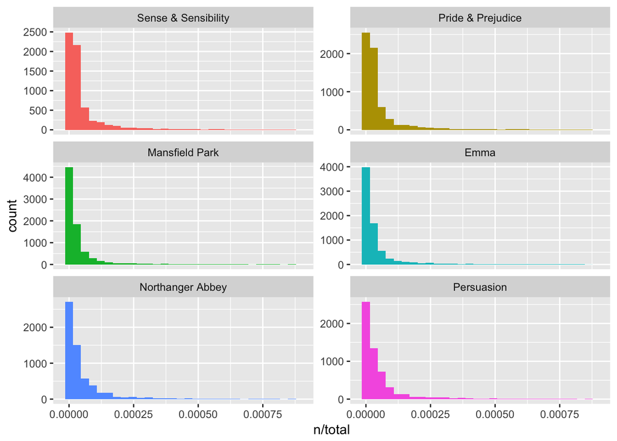

```r
ggplot(book_words, aes(n/total, fill = book)) +
  geom_histogram(show.legend = FALSE) +
  xlim(NA, 0.0009) +
  facet_wrap(~book, ncol = 2, scales = "free_y")
```

Zipf’s Law

Zipf’s Law: frequency that a word appears is inversely proportional to its rank.

```r
freq_by_rank <- book_words %>%
  group_by(book) %>%
  mutate(rank = row_number(),
         'term frequency' = n/total)

freq_by_rank
```

```
## Source: local data frame [40,379 x 6]
## Groups: book [6]
##
## # A tibble: 40,379 x 6
##                 book  word     n  total  rank `term frequency`
##               <fctr> <chr> <int>  <int> <int>            <dbl>
##  1    Mansfield Park   the  6206 160460     1       0.03867631
##  2    Mansfield Park    to  5475 160460     2       0.03412065
##  3    Mansfield Park   and  5438 160460     3       0.03389007
##  4              Emma    to  5239 160996     1       0.03254118
##  5              Emma   the  5201 160996     2       0.03230515
##  6              Emma   and  4896 160996     3       0.03041069
##  7    Mansfield Park    of  4778 160460     4       0.02977689
##  8 Pride & Prejudice   the  4331 122204     1       0.03544074
##  9              Emma    of  4291 160996     4       0.02665284
## 10 Pride & Prejudice    to  4162 122204     2       0.03405780
## # ... with 40,369 more rows
```

Graph of Zipf’s law for Jane Austen’s novels

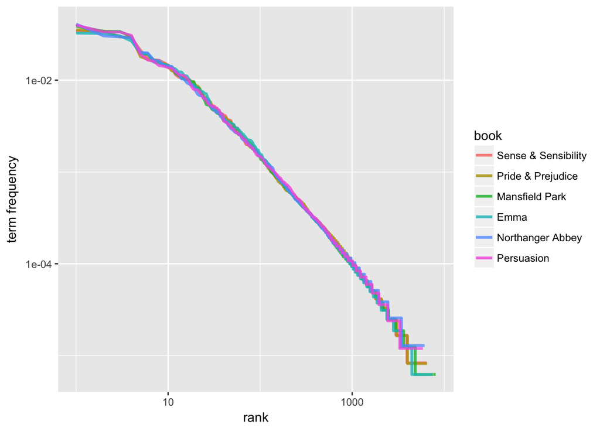

```r
freq_by_rank %>%
  ggplot(aes(rank, `term frequency`, color = book)) +
  geom_line(size = 1.1, alpha = 0.8, show.legend = TRUE) +
  scale_x_log10() +
  scale_y_log10()
```

```r
rank_subset <-  freq_by_rank %>%
  filter(rank <500,
         rank >10)


lm(log10(`term frequency`) ~ log10(rank), data = rank_subset)
```

```
##
## Call:
## lm(formula = log10(`term frequency`) ~ log10(rank), data = rank_subset)
##
## Coefficients:
## (Intercept)  log10(rank)
##     -0.6226      -1.1125
```

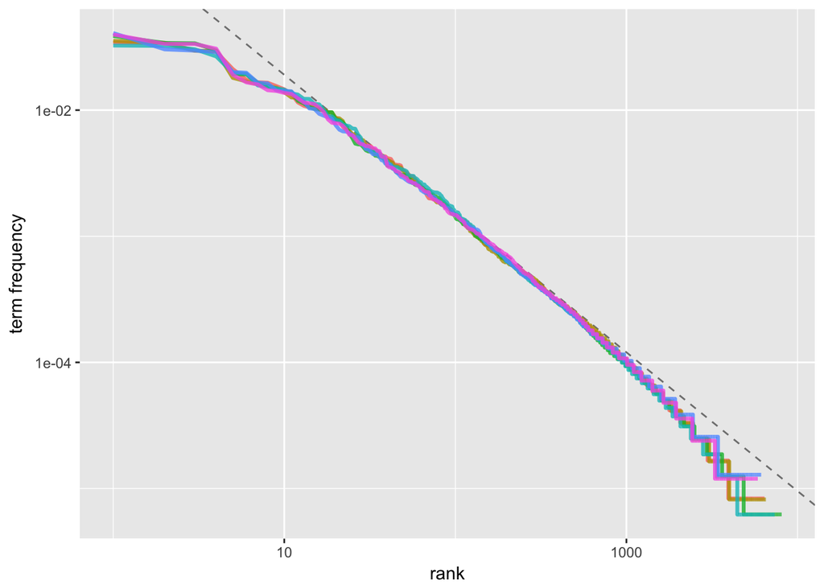

```r
freq_by_rank %>%
  ggplot(aes(rank, `term frequency`, color = book))+
  geom_abline(intercept = -0.62, slope = -1.1, color = "gray50", linetype = 2) +
  geom_line(size = 1.1, alpha = 0.8, show.legend = FALSE) +
  scale_x_log10() +
  scale_y_log10()
```

The bind_tf_idf Function

```r
book_words <- book_words %>%
  bind_tf_idf(word, book, n)

book_words
```

```
## # A tibble: 40,379 x 7
##                 book  word     n  total         tf   idf tf_idf
##               <fctr> <chr> <int>  <int>      <dbl> <dbl>  <dbl>
##  1    Mansfield Park   the  6206 160460 0.03867631     0      0
##  2    Mansfield Park    to  5475 160460 0.03412065     0      0
##  3    Mansfield Park   and  5438 160460 0.03389007     0      0
##  4              Emma    to  5239 160996 0.03254118     0      0
##  5              Emma   the  5201 160996 0.03230515     0      0
##  6              Emma   and  4896 160996 0.03041069     0      0
##  7    Mansfield Park    of  4778 160460 0.02977689     0      0
##  8 Pride & Prejudice   the  4331 122204 0.03544074     0      0
##  9              Emma    of  4291 160996 0.02665284     0      0
## 10 Pride & Prejudice    to  4162 122204 0.03405780     0      0
## # ... with 40,369 more rows
```

```r
book_words %>%
  select(-total) %>%
  arrange(desc(tf_idf))
```

```
## # A tibble: 40,379 x 6
##                   book      word     n          tf      idf      tf_idf
##                 <fctr>     <chr> <int>       <dbl>    <dbl>       <dbl>
##  1 Sense & Sensibility    elinor   623 0.005193528 1.791759 0.009305552
##  2 Sense & Sensibility  marianne   492 0.004101470 1.791759 0.007348847
##  3      Mansfield Park  crawford   493 0.003072417 1.791759 0.005505032
##  4   Pride & Prejudice     darcy   373 0.003052273 1.791759 0.005468939
##  5          Persuasion    elliot   254 0.003036171 1.791759 0.005440088
##  6                Emma      emma   786 0.004882109 1.098612 0.005363545
##  7    Northanger Abbey    tilney   196 0.002519928 1.791759 0.004515105
##  8                Emma    weston   389 0.002416209 1.791759 0.004329266
##  9   Pride & Prejudice    bennet   294 0.002405813 1.791759 0.004310639
## 10          Persuasion wentworth   191 0.002283105 1.791759 0.004090775
## # ... with 40,369 more rows
```

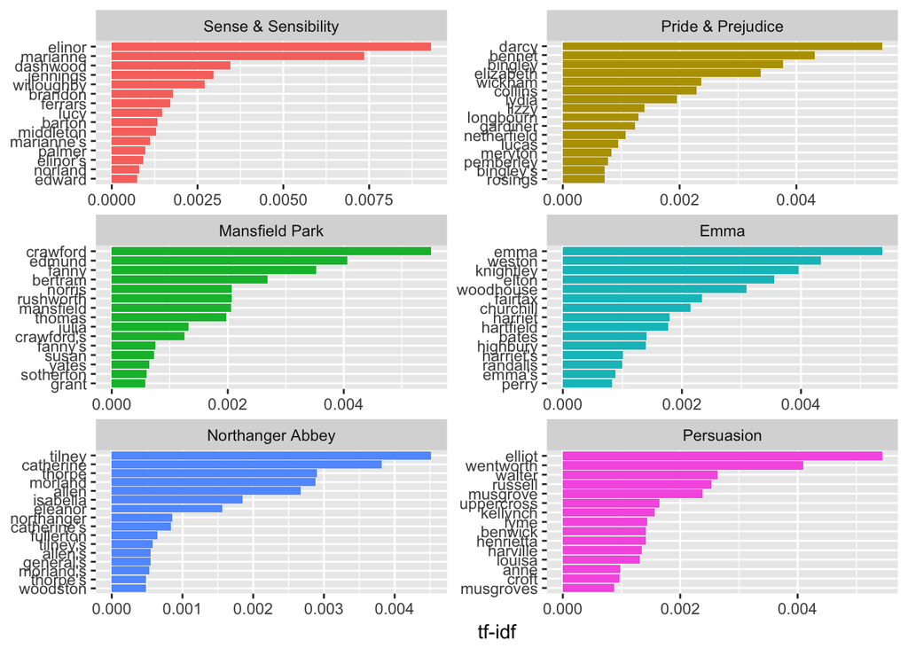

```r
book_words %>%
  arrange(desc(tf_idf)) %>%
  mutate(word = factor(word, levels = rev(unique(word)))) %>%
  group_by(book) %>%
  top_n(15) %>%
  ungroup() %>%
  ggplot(aes(word, tf_idf, fill = book)) +
  geom_col(show.legend = FALSE) +
  labs(x = NULL, y = "tf-idf") +
  facet_wrap(~book, ncol = 2,scales = "free") +
  coord_flip()
```

A corpus of Physics Text

```r
physics <- gutenberg_download(c(37729, 14725, 13476, 5001),
                              meta_fields = "author")
```

```r
physics_words <- physics %>%
  unnest_tokens(word, text) %>%
  count(author, word, sort = TRUE) %>%
  ungroup()

physics_words
```

```
## # A tibble: 12,592 x 3
##                 author  word     n
##                  <chr> <chr> <int>
##  1    Galilei, Galileo   the  3760
##  2       Tesla, Nikola   the  3604
##  3 Huygens, Christiaan   the  3553
##  4    Einstein, Albert   the  2994
##  5    Galilei, Galileo    of  2049
##  6    Einstein, Albert    of  2030
##  7       Tesla, Nikola    of  1737
##  8 Huygens, Christiaan    of  1708
##  9 Huygens, Christiaan    to  1207
## 10       Tesla, Nikola     a  1176
## # ... with 12,582 more rows
```

```r
author_order <- c("Galilei, Galileo", "Huygens, Christiaan", "Tesla, Nikola", "Einstein, Albert")

plot_physics <- physics_words %>%
  bind_tf_idf(word, author, n) %>%
  arrange(desc(tf_idf)) %>%
  mutate(word = factor(word, levels = rev(unique(word)))) %>%
  mutate(author = factor(author, levels = author_order))

plot_physics
```

```
## # A tibble: 12,592 x 6
##                 author          word     n          tf       idf
##                 <fctr>        <fctr> <int>       <dbl>     <dbl>
##  1    Einstein, Albert    relativity   192 0.006032424 1.3862944
##  2       Tesla, Nikola          bulb   171 0.004329662 1.3862944
##  3    Galilei, Galileo         water   828 0.020599065 0.2876821
##  4       Tesla, Nikola          coil   166 0.004203064 1.3862944
##  5       Tesla, Nikola          wire   133 0.003367515 1.3862944
##  6    Galilei, Galileo          hath   132 0.003283909 1.3862944
##  7 Huygens, Christiaan    refraction   218 0.005693987 0.6931472
##  8    Einstein, Albert        theory   181 0.005686817 0.6931472
##  9    Einstein, Albert gravitational    88 0.002764861 1.3862944
## 10    Galilei, Galileo        equall    98 0.002438054 1.3862944
## # ... with 12,582 more rows, and 1 more variables: tf_idf <dbl>
```

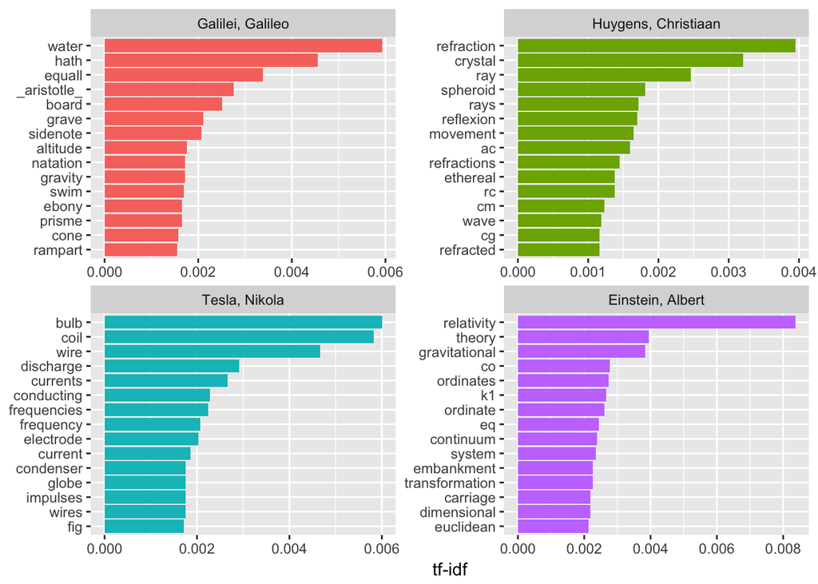

```r
plot_physics %>%
  group_by(author) %>%
  top_n(15, tf_idf) %>%
  ungroup() %>%
  mutate(word = reorder(word, tf_idf)) %>%
  ggplot(aes(word, tf_idf, fill = author)) +
  geom_col(show.legend = FALSE) +
  labs(x = NULL, y = "tf-idf") +
  facet_wrap(~author, ncol = 2, scales = "free") +
  coord_flip()
```

Isolating “eq” from Einstein’s text

```r
physics %>%
  filter(str_detect(text, "eq\\.")) %>%
  select(text)
```

```
## # A tibble: 55 x 1
##                                                               text
##                                                              <chr>
##  1                                            eq. 1: file eq01.gif
##  2                                            eq. 2: file eq02.gif
##  3                                            eq. 3: file eq03.gif
##  4                                            eq. 4: file eq04.gif
##  5                                         eq. 05a: file eq05a.gif
##  6                                         eq. 05b: file eq05b.gif
##  7                  the distance between the points being eq. 06 .
##  8 direction of its length with a velocity v is eq. 06 of a metre.
##  9                           velocity v=c we should have eq. 06a ,
## 10              the rod as judged from K1 would have been eq. 06 ;
## # ... with 45 more rows
```

K1 was used for the coordinate system for Einstein

```r
physics %>%
  filter(str_detect(text, "K1")) %>%
  select(text)
```

```
## # A tibble: 59 x 1
##                                                                      text
##                                                                     <chr>
##  1          to a second co-ordinate system K1 provided that the latter is
##  2         condition of uniform motion of translation. Relative to K1 the
##  3    tenet thus: If, relative to K, K1 is a uniformly moving co-ordinate
##  4  with respect to K1 according to exactly the same general laws as with
##  5 does not hold, then the Galileian co-ordinate systems K, K1, K2, etc.,
##  6  Relative to K1, the same event would be fixed in respect of space and
##  7  to K1, when the magnitudes x, y, z, t, of the same event with respect
##  8   of light (and of course for every ray) with respect to K and K1. For
##  9 reference-body K and for the reference-body K1. A light-signal is sent
## 10  immediately follows. If referred to the system K1, the propagation of
## # ... with 49 more rows
```

```r
physics %>%
  filter(str_detect(text, "AK")) %>%
  select(text)
```

```
## # A tibble: 34 x 1
##                                                                      text
##                                                                     <chr>
##  1  Now let us assume that the ray has come from A to C along AK, KC; the
##  2   be equal to the time along KMN. But the time along AK is longer than
##  3 that along AL: hence the time along AKN is longer than that along ABC.
##  4     And KC being longer than KN, the time along AKC will exceed, by as
##  5     line which is comprised between the perpendiculars AK, BL. Then it
##  6 ordinary refraction. Now it appears that AK and BL dip down toward the
##  7 side where the air is less easy to penetrate: for AK being longer than
##  8   than do AK, BL. And this suffices to show that the ray will continue
##  9     surface AB at the points AK_k_B. Then instead of the hemispherical
## 10 along AL, LB, and along AK, KB, are always represented by the line AH,
## # ... with 24 more rows
```

```r
mystopwords <- data_frame(word = c("eq","co","rc","ac","ak","bn",
                                   "fig", "file", "cg", "cb", "cm"))

physics_words <- anti_join(physics_words, mystopwords, by = "word")

plot_physics <- physics_words %>%
  bind_tf_idf(word, author, n) %>%
  arrange(desc(tf_idf)) %>%
  mutate(word = factor(word, levels = rev(unique(word)))) %>%
  group_by(author) %>%
  top_n(15, tf_idf) %>%
  ungroup() %>%
  mutate(author = factor(author, levels = author_order))

plot_physics
```

```
## # A tibble: 62 x 6
##                 author          word     n          tf       idf
##                 <fctr>        <fctr> <int>       <dbl>     <dbl>
##  1    Einstein, Albert    relativity   192 0.006077873 1.3862944
##  2       Tesla, Nikola          bulb   171 0.004340432 1.3862944
##  3    Galilei, Galileo         water   828 0.020599065 0.2876821
##  4       Tesla, Nikola          coil   166 0.004213519 1.3862944
##  5       Tesla, Nikola          wire   133 0.003375892 1.3862944
##  6    Galilei, Galileo          hath   132 0.003283909 1.3862944
##  7 Huygens, Christiaan    refraction   218 0.005731864 0.6931472
##  8    Einstein, Albert        theory   181 0.005729661 0.6931472
##  9    Einstein, Albert gravitational    88 0.002785692 1.3862944
## 10    Galilei, Galileo        equall    98 0.002438054 1.3862944
## # ... with 52 more rows, and 1 more variables: tf_idf <dbl>
```

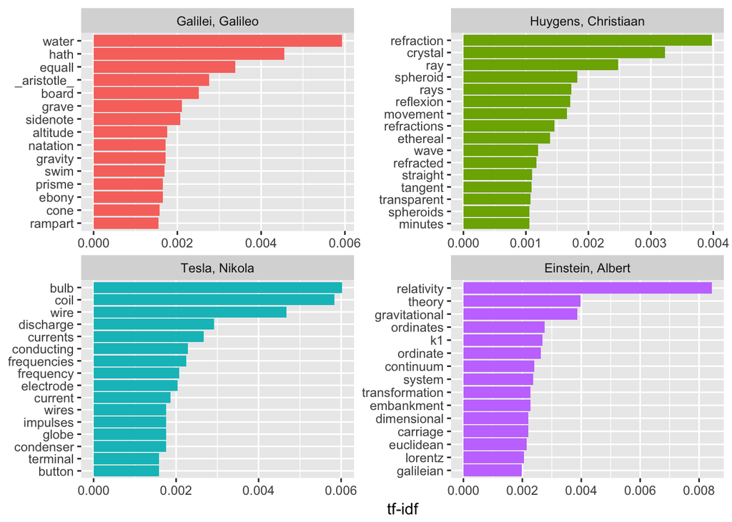

```r
ggplot(plot_physics, aes(word, tf_idf, fill = author)) +
  geom_col(show.legend = FALSE) +
  labs( x = NULL, y = "tf-idf") +
  facet_wrap(~author, ncol = 2, scales = "free") +
  coord_flip()
```

# Chapter 4 Relationships Between Words: N-grams and Correlations